# Google Data Analytics Certificate (Cyclistic)

Capstone Project

## Introduction

#### Lily Moreno, Director of Marketing for the Chicago area’s Cyclistic bike-share program, understood the company’s future success depended on a focused approach to marketing that maximized the number of annual memberships. I am a junior data analyst working with the marketing analyst team at Cyclistic. Ms Moreno needs analytics to inform her design marketing strategies that would help Cyclistic maximized the number of annual memberships.tactics. Moreno and her team are interested in analyzing the Cyclistic historical bike trip data to identify trends. Your team is tasked to present data with simple and compelling visualizations that will communicate insights for Cyclistic executives’decision making process.

#### This analysis is for case study 1 from the Google Data Analytics Certificate (Cyclistic). It’s originally based on the case study “‘Sophisticated, Clear, and Polished’: Divvy and Data Visualization” written by **Kevin Hartman** (found here: https://artscience.blog/home/divvy-dataviz-case-study).

#### We will follow the data analysis process: ask, prepare, process, analyze,share, and act to come up with a solution or make reccomendations for the business task

### **Business Task:** How can Cyclistic maximize the number of annual memberships?

## STEP 1: COLLECT DATA

#### We begin the analysis by loading the R packages needed for this exercise

```r
install.packages("tidyverse")
install.packages("lubridate")
install.packages("dplyr")
install.packages("ggplot2")
install.packages("ggthemes")
library(tidyverse)
library(lubridate)
library(dplyr)
library(ggplot2)
library(ggthemes)
getwd()
setwd("/Users/tushy/OneDrive/Desktop/Capstone Google/Capstone")
```

### STEP 1: COLLECT DATA

#### Loading data (12 months Starting October 2020 to end of September 2021 for this analysis)

```r
biketripdata_2020_10 <- read.csv("202010-divvy-tripdata.csv")
biketripdata_2020_11 <- read.csv("202011-divvy-tripdata.csv")
biketripdata_2020_12 <- read.csv("202012-divvy-tripdata.csv")
biketripdata_2021_01 <- read.csv("202101-divvy-tripdata.csv")
biketripdata_2021_02 <- read.csv("202102-divvy-tripdata.csv")
biketripdata_2021_03 <- read.csv("202103-divvy-tripdata.csv")
biketripdata_2021_04 <- read.csv("202104-divvy-tripdata.csv")
biketripdata_2021_05 <- read.csv("202105-divvy-tripdata.csv")
biketripdata_2021_06 <- read.csv("202106-divvy-tripdata.csv")
biketripdata_2021_07 <- read.csv("202107-divvy-tripdata.csv")
biketripdata_2021_08 <- read.csv("202108-divvy-tripdata.csv")
biketripdata_2021_09 <- read.csv("202109-divvy-tripdata.csv")
```

### STEP 2: WRANGLE DATA AND COMBINE INTO A SINGLE FILE

#### We need the all data to stack correctly when we combine the all the data for analysis. Some of the start_station_id’s and end_station_id’s need to be converted into characters format for this process.

```r
biketripdata_2020_10 <- mutate(biketripdata_2020_10, start_station_id = as.character(start_station_id), end_station_id = as.character(end_station_id))
biketripdata_2020_11 <- mutate(biketripdata_2020_11, start_station_id = as.character(start_station_id), end_station_id = as.character(end_station_id))
```

#### After the data is stacked correctly we bind all of our csv spreadsheets for analysis

```r
tot_biketrips <-bind_rows(
biketripdata_2020_10,
biketripdata_2020_11,
biketripdata_2020_12,
biketripdata_2021_01,
biketripdata_2021_02,
biketripdata_2021_03,
biketripdata_2021_04,
biketripdata_2021_05,
biketripdata_2021_06,
biketripdata_2021_07,
biketripdata_2021_08,
biketripdata_2021_09)
```

#### Inspect data to view changes and Clean before analysis using these functions: colnames()/summary()/head()

```r
colnames(tot_biketrips)
```

```
 [1] "ride_id"            "rideable_type"      "started_at"         "ended_at"
 [5] "start_station_name" "start_station_id"   "end_station_name"   "end_station_id"
 [9] "start_lat"          "start_lng"          "end_lat"            "end_lng"
[13] "member_casual"
```

```r
nrow(tot_biketrips)
```

```
[1] 5136261
```

```r
summary(tot_biketrips)
```

```
   ride_id          rideable_type       started_at          ended_at         start_station_name
 Length:5136261     Length:5136261     Length:5136261     Length:5136261     Length:5136261
 Class :character   Class :character   Class :character   Class :character   Class :character
 Mode  :character   Mode  :character   Mode  :character   Mode  :character   Mode  :character




 start_station_id   end_station_name   end_station_id       start_lat       start_lng
 Length:5136261     Length:5136261     Length:5136261     Min.   :41.64   Min.   :-87.84
 Class :character   Class :character   Class :character   1st Qu.:41.88   1st Qu.:-87.66
 Mode  :character   Mode  :character   Mode  :character   Median :41.90   Median :-87.64
                                                          Mean   :41.90   Mean   :-87.65
                                                          3rd Qu.:41.93   3rd Qu.:-87.63
                                                          Max.   :42.08   Max.   :-87.52

    end_lat         end_lng       member_casual
 Min.   :41.51   Min.   :-88.07   Length:5136261
 1st Qu.:41.88   1st Qu.:-87.66   Class :character
 Median :41.90   Median :-87.64   Mode  :character
 Mean   :41.90   Mean   :-87.65
 3rd Qu.:41.93   3rd Qu.:-87.63
 Max.   :42.17   Max.   :-87.44
 NA's   :4821    NA's   :4821
```

```r
colnames(tot_biketrips)
```

```
 [1] "ride_id"            "rideable_type"      "started_at"         "ended_at"
 [5] "start_station_name" "start_station_id"   "end_station_name"   "end_station_id"
 [9] "start_lat"          "start_lng"          "end_lat"            "end_lng"
[13] "member_casual"
```

```r
nrow(tot_biketrips)
```

```
[1] 5136261
```

```r
summary(tot_biketrips)
```

```
   ride_id          rideable_type       started_at          ended_at         start_station_name
 Length:5136261     Length:5136261     Length:5136261     Length:5136261     Length:5136261
 Class :character   Class :character   Class :character   Class :character   Class :character
 Mode  :character   Mode  :character   Mode  :character   Mode  :character   Mode  :character




 start_station_id   end_station_name   end_station_id       start_lat       start_lng
 Length:5136261     Length:5136261     Length:5136261     Min.   :41.64   Min.   :-87.84
 Class :character   Class :character   Class :character   1st Qu.:41.88   1st Qu.:-87.66
 Mode  :character   Mode  :character   Mode  :character   Median :41.90   Median :-87.64
                                                          Mean   :41.90   Mean   :-87.65
                                                          3rd Qu.:41.93   3rd Qu.:-87.63
                                                          Max.   :42.08   Max.   :-87.52

    end_lat         end_lng       member_casual
 Min.   :41.51   Min.   :-88.07   Length:5136261
 1st Qu.:41.88   1st Qu.:-87.66   Class :character
 Median :41.90   Median :-87.64   Mode  :character
 Mean   :41.90   Mean   :-87.65
 3rd Qu.:41.93   3rd Qu.:-87.63
 Max.   :42.17   Max.   :-87.44
 NA's   :4821    NA's   :4821
```

```r
head(tot_biketrips)
```

|  | ride_id | rideable_type | started_at | ended_at | start_station_name | start_station_id | end_station_name | end_station_id | start_lat | start_lng | end_lat | end_lng | member_casual |
| --- | --- | --- | --- | --- | --- | --- | --- | --- | --- | --- | --- | --- | --- |
| 1 | ACB6B40CF5B9044C | electric_bike | 2020-10-31 19:39:43 | 2020-10-31 19:57:12 | Lakeview Ave & Fullerton Pkwy | 313 | Rush St & Hubbard St | 125 | 41.92610 | -87.63898 | 41.89035 | -87.62607 | casual |
| 2 | DF450C72FD109C01 | electric_bike | 2020-10-31 23:50:08 | 2020-11-01 00:04:16 | Southport Ave & Waveland Ave | 227 | Kedzie Ave & Milwaukee Ave | 260 | 41.94817 | -87.66391 | 41.92953 | -87.70782 | casual |
| 3 | B6396B54A15AC0DF | electric_bike | 2020-10-31 23:00:01 | 2020-10-31 23:08:22 | Stony Island Ave & 67th St | 102 | University Ave & 57th St | 423 | 41.77346 | -87.58537 | 41.79145 | -87.60005 | casual |
| 4 | 44A4AEE261B9E854 | electric_bike | 2020-10-31 22:16:43 | 2020-10-31 22:19:35 | Clark St & Grace St | 165 | Broadway & Sheridan Rd | 256 | 41.95085 | -87.65924 | 41.95281 | -87.65010 | casual |
| 5 | 10B7DD76A6A2EB95 | electric_bike | 2020-10-31 19:38:19 | 2020-10-31 19:54:32 | Southport Ave & Wrightwood Ave | 190 | Stave St & Armitage Ave | 185 | 41.92886 | -87.66396 | 41.91778 | -87.69143 | casual |
| 6 | DA6C3759660133DA | electric_bike | 2020-10-29 17:38:04 | 2020-10-29 17:45:43 | Larrabee St & Division St | 359 | Wells St & Huron St | 53 | 41.90353 | -87.64335 | 41.89440 | -87.63431 | casual |

[output not shown]

## STEP 3: CLEAN UP AND ADD DATA TO PREPARE FOR ANALYSIS

#### In order to do further cleaning and calculations, we must add dates of columns to the cleaned data set such as day, week, month and year.

```r
tot_biketrips_clean$date <- as.Date(tot_biketrips_clean$started_at)
tot_biketrips_clean$month <- format(as.Date(tot_biketrips_clean$date), "%m")
tot_biketrips_clean$day <- format(as.Date(tot_biketrips_clean$date), "%d")
tot_biketrips_clean$year <- format(as.Date(tot_biketrips_clean$date), "%Y")
tot_biketrips_clean$day_of_week <- format(as.Date(tot_biketrips_clean$date), "%A")
```

### check out rows to see if the date columns were added

```r
glimpse(tot_biketrips_clean)
```

```
Rows: 5,045,921
Columns: 18
$ ride_id            <chr> "ACB6B40CF5B9044C", "DF450C72FD109C01", "B6396B54A15AC0DF", "44A4AEE261~
$ rideable_type      <chr> "electric_bike", "electric_bike", "electric_bike", "electric_bike", "el~
$ started_at         <chr> "2020-10-31 19:39:43", "2020-10-31 23:50:08", "2020-10-31 23:00:01", "2~
$ ended_at           <chr> "2020-10-31 19:57:12", "2020-11-01 00:04:16", "2020-10-31 23:08:22", "2~
$ start_station_name <chr> "Lakeview Ave & Fullerton Pkwy", "Southport Ave & Waveland Ave", "Stony~
$ start_station_id   <chr> "313", "227", "102", "165", "190", "359", "313", "125", "174", "114", "~
$ end_station_name   <chr> "Rush St & Hubbard St", "Kedzie Ave & Milwaukee Ave", "University Ave &~
$ end_station_id     <chr> "125", "260", "423", "256", "185", "53", "125", "313", "635", "303", "1~
$ start_lat          <dbl> 41.92610, 41.94817, 41.77346, 41.95085, 41.92886, 41.90353, 41.92584, 4~
$ start_lng          <dbl> -87.63898, -87.66391, -87.58537, -87.65924, -87.66396, -87.64335, -87.6~
$ end_lat            <dbl> 41.89035, 41.92953, 41.79145, 41.95281, 41.91778, 41.89440, 41.89047, 4~
$ end_lng            <dbl> -87.62607, -87.70782, -87.60005, -87.65010, -87.69143, -87.63431, -87.6~
$ member_casual      <chr> "casual", "casual", "casual", "casual", "casual", "casual", "casual", "~
$ date               <date> 2020-10-31, 2020-10-31, 2020-10-31, 2020-10-31, 2020-10-31, 2020-10-29~
$ month              <chr> "10", "10", "10", "10", "10", "10", "10", "10", "10", "10", "10", "10",~
$ day                <chr> "31", "31", "31", "31", "31", "29", "29", "29", "29", "28", "29", "29",~
$ year               <chr> "2020", "2020", "2020", "2020", "2020", "2020", "2020", "2020", "2020",~
$ day_of_week        <chr> "Saturday", "Saturday", "Saturday", "Saturday", "Saturday", "Thursday",~
```

### Add a “ride_length” calculation to tot_biketrips cleaned (in seconds)

```r
tot_biketrips_clean$ride_length <- difftime(tot_biketrips_clean$ended_at,tot_biketrips_clean$started_at)
```

### Remove “bad” data for bikes taken out of circulation in order to omit negative values in ride length

```r
tot_biketrips_v2 <- tot_biketrips_clean[!(tot_biketrips_clean$start_station_name == "HQ QR" | tot_biketrips_clean$ride_length<0),]
```

## STEP 4: CONDUCT DESCRIPTIVE ANALYSIS

```r
min(tot_biketrips_v2$ride_length) # shortest ride
```

```
[1] 0
```

```r
max(tot_biketrips_v2$ride_length) # longest ride
```

```
[1] 3356649
```

```r
mean(tot_biketrips_v2$ride_length) # average (total ride length / rides)
```

```
[1] 1326.167
```

```r
median(tot_biketrips_v2$ride_length) # midpoint
```

```
[1] 757
```

```r
summary(tot_biketrips_v2)
```

```
   ride_id          rideable_type       started_at          ended_at         start_station_name
 Length:5042638     Length:5042638     Length:5042638     Length:5042638     Length:5042638
 Class :character   Class :character   Class :character   Class :character   Class :character
 Mode  :character   Mode  :character   Mode  :character   Mode  :character   Mode  :character



 start_station_id   end_station_name   end_station_id       start_lat       start_lng
 Length:5042638     Length:5042638     Length:5042638     Min.   :41.64   Min.   :-87.84
 Class :character   Class :character   Class :character   1st Qu.:41.88   1st Qu.:-87.66
 Mode  :character   Mode  :character   Mode  :character   Median :41.90   Median :-87.64
                                                          Mean   :41.90   Mean   :-87.65
                                                          3rd Qu.:41.93   3rd Qu.:-87.63
                                                          Max.   :42.07   Max.   :-87.52
    end_lat         end_lng       member_casual           date               month
 Min.   :41.51   Min.   :-88.07   Length:5042638     Min.   :2020-10-01   Length:5042638
 1st Qu.:41.88   1st Qu.:-87.66   Class :character   1st Qu.:2021-04-18   Class :character
 Median :41.90   Median :-87.64   Mode  :character   Median :2021-06-23   Mode  :character
 Mean   :41.90   Mean   :-87.65                      Mean   :2021-05-29
 3rd Qu.:41.93   3rd Qu.:-87.63                      3rd Qu.:2021-08-12
 Max.   :42.17   Max.   :-87.49                      Max.   :2021-09-30
     day                year           day_of_week         ride_length
 Length:5042638     Length:5042638     Length:5042638     Min.   :      0
 Class :character   Class :character   Class :character   1st Qu.:    427
 Mode  :character   Mode  :character   Mode  :character   Median :    757
                                                          Mean   :   1326
                                                          3rd Qu.:   1369
                                                          Max.   :3356649
```

### Compare members and casual users

```r
aggregate(tot_biketrips_v2$ride_length ~ tot_biketrips_v2$member_casual, FUN = mean)
aggregate(tot_biketrips_v2$ride_length ~ tot_biketrips_v2$member_casual, FUN = median)
aggregate(tot_biketrips_v2$ride_length ~ tot_biketrips_v2$member_casual, FUN = max)
aggregate(tot_biketrips_v2$ride_length ~ tot_biketrips_v2$member_casual, FUN = min)
```

[output not shown]

### See the average ride time by each day for members vs casual users

```r
aggregate(tot_biketrips_v2$ride_length ~ tot_biketrips_v2$member_casual + tot_biketrips_v2$day_of_week, FUN = mean)
```

| tot_biketrips_v2$member_casual | tot_biketrips_v2$day_of_week | tot_biketrips_v2$ride_length |
| --- | --- | --- |
| casual | Friday | 1819.9010 |
| member | Friday | 823.9347 |
| casual | Monday | 1885.4267 |
| member | Monday | 803.7666 |
| casual | Saturday | 2067.1800 |
| member | Saturday | 926.4486 |
| casual | Sunday | 2213.0851 |
| member | Sunday | 943.8355 |
| casual | Thursday | 1633.4148 |
| member | Thursday | 783.7299 |

[output cut: 4 more lines]

[output not shown]

### Organize the week days

```r
tot_biketrips_v2$day_of_week <- ordered(tot_biketrips_v2$day_of_week, levels=c("Sunday", "Monday", "Tuesday", "Wednesday", "Thursday", "Friday", "Saturday"))
```

### Detemine the average ride time by each day for members vs casual users

```r
aggregate(tot_biketrips_v2$ride_length ~ tot_biketrips_v2$member_casual + tot_biketrips_v2$day_of_week, FUN = mean)
```

| tot_biketrips_v2$member_casual | tot_biketrips_v2$day_of_week | tot_biketrips_v2$ride_length |
| --- | --- | --- |
| casual | Sunday | 2213.0851 |
| member | Sunday | 943.8355 |
| casual | Monday | 1885.4267 |
| member | Monday | 803.7666 |
| casual | Tuesday | 1702.6415 |
| member | Tuesday | 786.1274 |
| casual | Wednesday | 1657.3003 |
| member | Wednesday | 790.6077 |
| casual | Thursday | 1633.4148 |
| member | Thursday | 783.7299 |

[output cut: 4 more lines]

[output not shown]

### Analyze ridership data by type and weekday

```r
tot_biketrips_v2 %>%
mutate(weekday = wday(started_at, label = TRUE)) %>%  #creates weekday field using wday()
group_by(member_casual, weekday) %>%  #groups by usertype and weekday
summarise(number_of_rides = n()                         #calculates the number of rides and average duration
,average_duration = mean(ride_length)) %>%      # calculates the average duration
arrange(member_casual, weekday)                             # sorts
```

| member_casual | weekday | number_of_rides | average_duration |
| --- | --- | --- | --- |
| casual | Sun | 438955 | 2213.0851 |
| casual | Mon | 262243 | 1885.4267 |
| casual | Tue | 247212 | 1702.6415 |
| casual | Wed | 252639 | 1657.3003 |
| casual | Thu | 269059 | 1633.4148 |
| casual | Fri | 332637 | 1819.9010 |
| casual | Sat | 514655 | 2067.1800 |
| member | Sun | 338824 | 943.8355 |
| member | Mon | 369040 | 803.7666 |
| member | Tue | 400265 | 786.1274 |

[output cut: 4 more lines]

[output not shown]

```r
View(tot_biketrips_v2)
```

## STEP 5: VISUALIZATION SECTION

### Visualize the number of rides by rider type

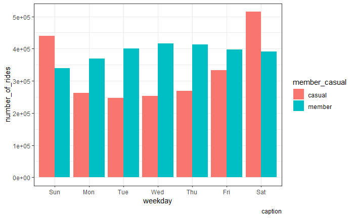

```r
tot_biketrips_v2 %>%
  mutate(weekday = wday(started_at, label = TRUE)) %>%
  group_by(member_casual, weekday) %>%
  summarise(number_of_rides = n()
            ,average_duration = mean(ride_length)) %>%
  arrange(member_casual, weekday)  %>%
  ggplot(aes(x = weekday, y = number_of_rides, fill = member_casual, caption = "Data by Motivate International Inc")) +
  geom_col(position = "dodge")+
  theme_bw()
```

```r
NA
NA
```

### Visualization for average duration of rides

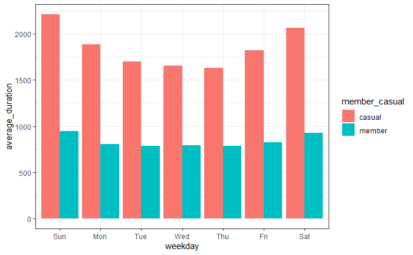

### Matching rider with type of bike

```r
  type_of_bike <- tot_biketrips_clean %>% filter(rideable_type=="classic_bike" | rideable_type=="electric_bike")
```

### checking the bike type usage by user type

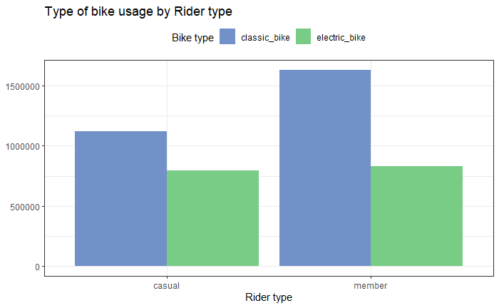

```r
  type_of_bike %>%
group_by(member_casual,rideable_type) %>%
    summarise(totals=n(), .groups="drop")  %>%

ggplot()+
    geom_col(aes(x=member_casual,y=totals,fill=rideable_type), position = "dodge") +
    labs(title = "Type of bike usage by Rider type",x="Rider type",y=NULL, fill="Bike type") +
    scale_fill_manual(values = c("classic_bike" = "#7291C9","electric_bike" = "#79CC85")) +
    theme_bw() +
    theme(legend.position="top")
```

### Bike usage by both user types during a week

[figure not shown]

```r
  type_of_bike %>%
    mutate(weekday = wday(started_at, label = TRUE)) %>%
    group_by(member_casual,rideable_type,weekday) %>%
    summarise(totals=n(), .groups="drop") %>%

ggplot(aes(x=weekday,y=totals, fill=rideable_type)) +
  geom_col(position = "dodge") +
  facet_wrap(~member_casual) +
  labs(title = "Bike type usage by user type during a week",x="User type",y=NULL,caption = "Data by Motivate International Inc") +
  scale_fill_manual(values = c("classic_bike" = "#7291C9","electric_bike" = "#79CC85")) +
  theme_bw() +
  theme(legend.position="top")
```

```r
NA
NA
NA
```